# Evaluation of detection dog

Shoshana Rapley

10 April 2025

# 1 Introduction

# 2 Power Analysis

## 2.1 Dog only

How many trials needed to determine dog performs better than sensitivity 0.5? Sensitivity at which the dog is a worthwhile approach will depend on the application. For some purposes, such as medical detection or law enforcement, sensitivity may need to be >0.9. Whereas other applications, such as detection of scats, missing some and a sensitivity of 0.5 may be appropriate.

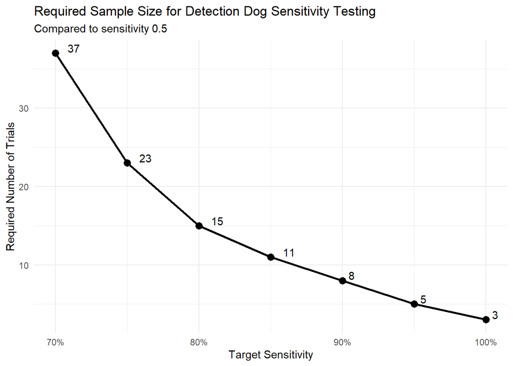

```r
# Function to calculate required sample size for proportion test
dog_sensitivity_power <- function(
  target_sensitivity = 0.9,   # Predicted sensitivity (true positive rate)
  null_sensitivity = 0.5,     # Null hypothesis value
  power = 0.8,               # Desired power
  alpha = 0.05,              # Significance level
  alternative = "greater"    # One sided test
) {

  # Effect size calculation (h) for proportion test
  h <- ES.h(p1 = target_sensitivity, p2 = null_sensitivity)

  # Calculate required sample size using pwr.p.test
  result <- pwr.p.test(h = h,
                     sig.level = alpha,
                     power = power,
                     alternative = alternative)

  # Return sample size (rounded up)
  return(ceiling(result$n))
}

# Create a function to explore different sensitivity scenarios
sensitivity_scenarios <- function(
  sensitivities = seq(0.7, 1, by = 0.05),
  null_values = c(0.5),
  power_values = c(0.8),
  alpha = 0.05
) {

  # Create a grid of all combinations
  scenarios <- expand_grid(
    target_sensitivity = sensitivities,
    null_sensitivity = null_values,
    power = power_values,
    alpha = alpha
  )

  # Calculate required sample size for each combination
  scenarios <- scenarios %>%
    rowwise() %>%
    mutate(sample_size = dog_sensitivity_power(
      target_sensitivity = target_sensitivity,
      null_sensitivity = null_sensitivity,
      power = power,
      alpha = alpha
    )) %>%
    ungroup()

  return(scenarios)
}

# Generate scenarios
scenarios <- sensitivity_scenarios()

# Plot
ggplot(scenarios,
       aes(x = target_sensitivity, y = sample_size, label  = sample_size)) +
  geom_line(linewidth = 1) +
  geom_point(size = 3) +
  geom_text(hjust = -1, vjust = -0.1)+
  scale_x_continuous(labels = scales::percent_format(accuracy = 1)) +
  labs(title = "Required Sample Size for Detection Dog Sensitivity Testing",
    subtitle = "Compared to sensitivity 0.5",
    x = "Target Sensitivity",
    y = "Required Number of Trials") +
  theme_minimal()
```

## 2.2 Dog and human

How many trials needed to determine dog performs better than human?

This is probably the better way to go, because the purpose of the study is to demonstrate that the dog is better than alternative methods - which in this case is human search. In other dog studies alternative methods might be, for example, live trapping or thermal camera imaging.

Originally estimated at 80% for Koda and 30% for human, result of field trial was 100% for Koda and 40% for human.

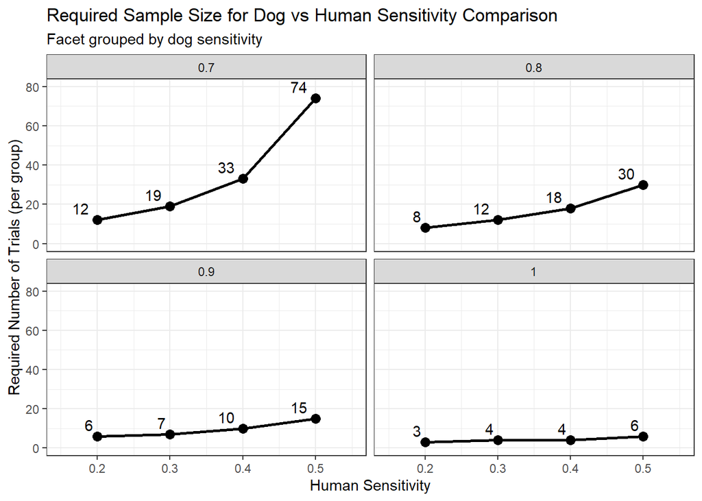

```r
compare_sensitivity_power <- function(
  dog_sensitivity = 1,    # Expected dog sensitivity
  human_sensitivity = 0.4,  # Expected human sensitivity
  power = 0.8,              # Desired power )
  alpha = 0.05,             # Significance level
  alternative = "greater"   # One-sided dog > human
) {

  # Effect size calculation (h) for proportion test
  h <- ES.h(p1 = dog_sensitivity, p2 = human_sensitivity)

  # Calculate required sample size using pwr.2p.test
  # This function is for two proportions with equal sample sizes
  result <- pwr.2p.test(h = h,
                        n = NULL,
                        sig.level = alpha,
                        power = power,
                        alternative = alternative)

  # Return sample size (rounded up)
  # For pwr.2p.test, n1 = n2 = n (equal sample sizes)
  sample_size = ceiling(result$n)

  return(list(
    n1 = sample_size,  # Dog sample size
    n2 = sample_size   # Human sample size
  ))
}

# Create a function to explore different comparison scenarios
comparison_scenarios <- function(
  dog_sensitivities = seq(0.7, 1, by = 0.1),
  human_sensitivities = seq(0.2, 0.5, by = 0.1),
  power_values = c(0.8),
  alpha = 0.05
) {

  # Create a grid of all combinations
  scenarios <- expand_grid(
    dog_sensitivity = dog_sensitivities,
    human_sensitivity = human_sensitivities,
    power = power_values,
    alpha = alpha
  )

  # Calculate required sample size for each combination
  scenarios <- scenarios %>%
    rowwise() %>%
    mutate(
      sample_result = list(compare_sensitivity_power(
        dog_sensitivity = dog_sensitivity,
        human_sensitivity = human_sensitivity,
        power = power,
        alpha = alpha
      )),
      dog_sample = sample_result$n1,
      human_sample = sample_result$n2
    ) %>%
    select(-sample_result) %>%
    ungroup()

  return(scenarios)
}

# Generate dog vs human comparison scenarios
comparison <- comparison_scenarios()

# Create a visualization of the comparison scenarios
ggplot(comparison,
       aes(x = human_sensitivity, y = dog_sample, label = dog_sample))+
  geom_line(linewidth = 1) +
  geom_point(size = 3) +
  geom_text(hjust = 1.5, vjust = -0.5)+
  scale_x_continuous(labels = scales::percent_format(accuracy = 1)) +
  xlim(c(0.15, 0.55))+
  ylim(c(0, 80))+
  labs(
    title = "Required Sample Size for Dog vs Human Sensitivity Comparison",
    subtitle = "Facet grouped by dog sensitivity",
    x = "Human Sensitivity",
    y = "Required Number of Trials (per group)",
    colour = "Human Sensitivity",
    linetype = "Statistical Power"
  ) +
  theme_bw()+
  facet_wrap(~dog_sensitivity)
```

# 3 Statistics

## 3.1 Summary stats

What were the sensitivity, precision and efficiency of the dog and human? Create confusion matrix to report results.

Definitions:

- Sensitivity: proportion of targets found relative to total number available
- Precision: proportion of alerts directed to a true target
- Efficiency: performance per unit effort

### 3.1.1 Dog summary

Calculate performance metrics for the dog-handler team.

Search time does not include the negative tests, because these were to test true/false positive/negatives not speed - the presence tests are for speed, and are directly comparable to the human only tests (which were presence only).

```r
# read in dog data
dog_data <- read_xlsx("detection field test data.xlsx", sheet = "dog") %>%
  clean_names() %>%
  # convert NA strings to NAs
  mutate(across(where(is.character), ~na_if(., "NA"))) %>%
  # create binary expected and real values
  mutate(expected = as_factor(ifelse(type == "ABSENCE", 0, 1)),
         real = as_factor(ifelse(found == "TRUE", 1, 0))) %>%
  # omit excluded find, where "found" is NA
  drop_na(found)

# calculate true/false postive/negative results
dog_results <- dog_data %>%
  summarise(
    type = "dog",
    true_pos = sum(expected == 1 & real == 1),
    false_pos = sum(expected == 0 & real == 1),
    true_neg = sum(expected == 0 & real == 0),
    false_neg = sum(expected == 1 & real == 0)
    )
# calculate search time for presence searches only
search <- dog_data %>%
  filter(type == "PRESENCE") %>%
  summarise(mean = mean(search_time_s))

# summarise performance metrics
dog_summary <- dog_results %>%
  summarise(
    type = "dog",
    # true positive rate
    sensitivity = true_pos / (true_pos + false_neg),
    # false positive rate
    precision = true_pos / (true_pos + false_pos),
    # mean search time in minutes
    time = search$mean/60,
    # sensitivity divided by time, x 100 to be >0
    efficiency  = sensitivity / time * 100
  )

dog_summary
```

```
## # A tibble: 1 × 5
##   type  sensitivity precision  time efficiency
##   <chr>       <dbl>     <dbl> <dbl>      <dbl>
## 1 dog             1         1  6.45       15.5
```

type sensitivity precision time efficiency 1 dog 1 1 6.45 15.5

### 3.1.2 Human summary

Calculate performance metrics for the human-only searches.

Note - trials were presence only.

```r
# read in human results
human_data <- read_xlsx("detection field test data.xlsx", sheet = "human") %>%
  clean_names() %>%
  # convert NA strings to NAs
  mutate(across(where(is.character), ~na_if(., "NA"))) %>%
  # create binary expected (all positive) and real values
  mutate(expected = as_factor(1),
         real = as_factor(ifelse(found == "TRUE", 1, 0)))

# calculate true/false postive/negative results
human_results <- human_data %>%
  summarise(
    type = "human",
    true_pos = sum(expected == 1 & real == 1),
    false_pos = sum(expected == 0 & real == 1),
    true_neg = sum(expected == 0 & real == 0),
    false_neg = sum(expected == 1 & real == 0)
    )

human_summary <- human_results %>%
  summarise(
    type = "human",
    # true positive rate
    sensitivity = true_pos / (true_pos + false_neg),
    # false positive rate
    precision = true_pos / (true_pos + false_pos),
    # mean search time in minutes
    time = mean(human_data$search_time_s)/60,
    # sensitivity divided by time, x 100 to be >0
    efficiency  = sensitivity / time * 100
  )

human_summary
```

```
## # A tibble: 1 × 5
##   type  sensitivity precision  time efficiency
##   <chr>       <dbl>     <dbl> <dbl>      <dbl>
## 1 human       0.429         1  43.9      0.977
```

type sensitivity precision time efficiency 1 human 0.429 1 43.9 0.977

### 3.1.3 Both summary

Combine data and plot outcomes.

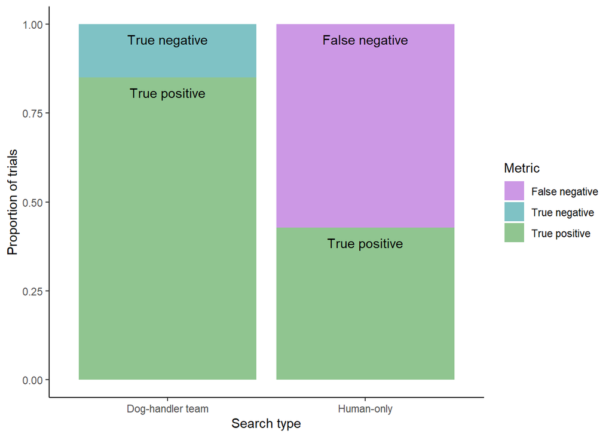

```r
# both counts
counts <- rbind(dog_results, human_results)

# format for bar plot (including nicer names in the mutate case when)
counts2 <- counts %>%
  pivot_longer(2:5, values_to = "count", names_to = "metric") %>%
  filter(!count == 0) %>%
  mutate(
    name = case_when(
      metric == "true_pos" ~ "True positive",
      metric == "true_neg" ~ "True negative",
      metric == "false_neg" ~ "False negative"),
    type = case_when(
      type == "dog" ~ "Dog-handler team",
      type == "human" ~ "Human-only"))

# both performance metrics
performance <- rbind(dog_summary, human_summary)

# plot
plot1 <- ggplot(counts2)+
  geom_bar(aes(x = type, y= count, fill = name),
           position = "fill", stat = "identity",
           alpha = 0.5)+
  geom_text(aes(x = type, y= count, label = name),
            position = "fill", stat = "identity",
            vjust = 2)+
  scale_fill_manual(values = c("darkorchid", "turquoise4", "forestgreen"), name = "Metric")+
  theme_classic()+
  ylab("Proportion of trials")+
  xlab("Search type")

plot1
```

## 3.2 Time comparison

```r
# combine times dataframe
dog_time <- dog_data %>%
  filter(type == "PRESENCE") %>%
  select(search_time_s) %>%
  mutate(type = "dog")

human_time <- human_data %>%
  select(search_time_s) %>%
  mutate(type = "human")

times <- rbind(dog_time, human_time) %>%
  rename(time = search_time_s)

# one sided t test
m1 <- t.test(time ~ type, data = times, alternative = "less")
m1
```

```
##
##  Welch Two Sample t-test
##
## data:  time by type
## t = -7.3463, df = 15.378, p-value = 1.044e-06
## alternative hypothesis: true difference in means between group dog and group human is less than 0
## 95 percent confidence interval:
##      -Inf -1710.63
## sample estimates:
##   mean in group dog mean in group human
##            386.7059           2632.3571
```

```r
# approx 95% conf intervals using t distribution
conf <- times %>%
  group_by(type) %>%
  summarise(mean = mean(time),
            se = std.error(time),
            n = length(time)) %>%
  mutate(upper = (mean + qt(0.975, n-1) * se)/60,
         lower = (mean - qt(0.975, n-1) * se)/60)

conf
```

```
## # A tibble: 2 × 6
##   type   mean    se     n upper lower
##   <chr> <dbl> <dbl> <int> <dbl> <dbl>
## 1 dog    387.  88.4    17  9.57  3.32
## 2 human 2632. 293.     14 54.4  33.3
```

**Results**: Welch Two Sample t-test: t = -7.3463, df = 15.378, p-value = 1.044e-06

95% confidence intervals: type mean se n upper lower 1 dog 387. 88.4 17 9.57 3.32 2 human 2632. 293. 14 54.4 33.3

Yes, the dog is significantly faster (p < 0.0001).

Plot search times.

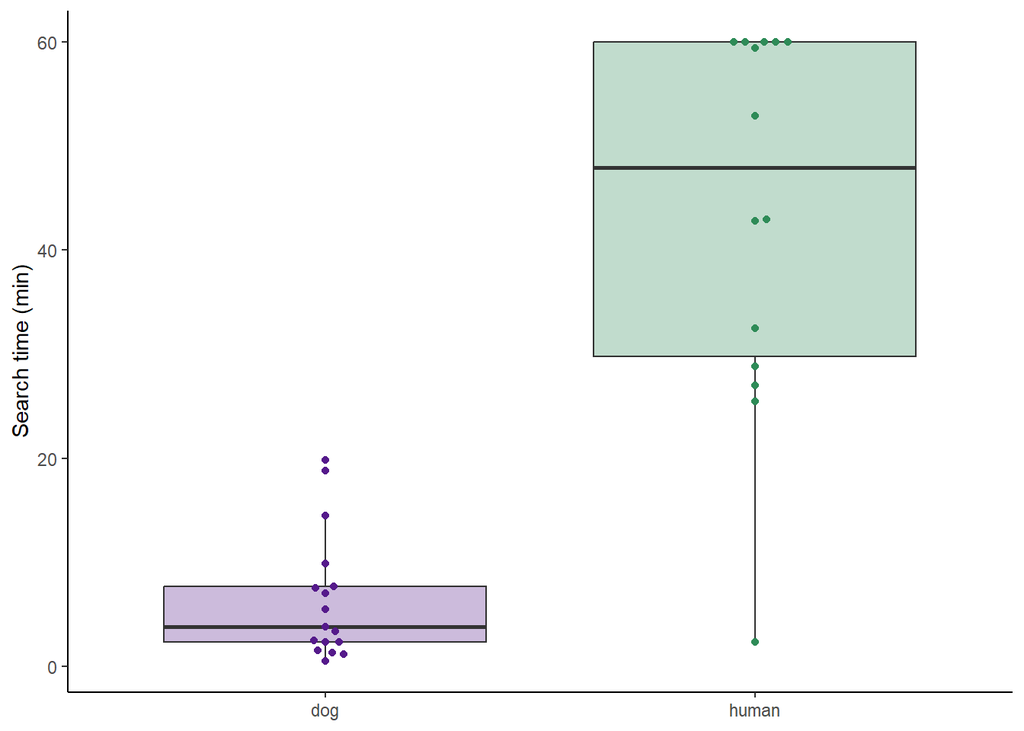

```r
# coloured version for poster
colours <- c("purple4", "seagreen4")
ggplot(times, aes(type, time/60))+
  geom_boxplot(aes(fill = type), alpha = 0.3, outlier.shape = NA)+
  geom_beeswarm(aes(colour = type), spacing = 1, method = "compactswarm")+
  scale_fill_manual(values = colours)+
  scale_colour_manual(values = colours)+
  theme_classic()+
  ylab("Search time (min)")+
  xlab(NULL)+
  theme(legend.position = "none")
```

```r
ggsave("search_times_poster.png", height = 6, width = 6, units = "cm", dpi = 600)

# B&W version for paper
plot2 <- ggplot(times, aes(type, time/60))+
  geom_boxplot(outlier.shape = NA)+
  geom_beeswarm(spacing = 2, method = "compactswarm")+
  theme_classic()+
  ylab("Search time (min)")+
  xlab("Search type")+
  scale_x_discrete(labels = c("Dog-handler team", "Human-only"))
```

## 3.3 Figure

Combined plot of performance metric and search time

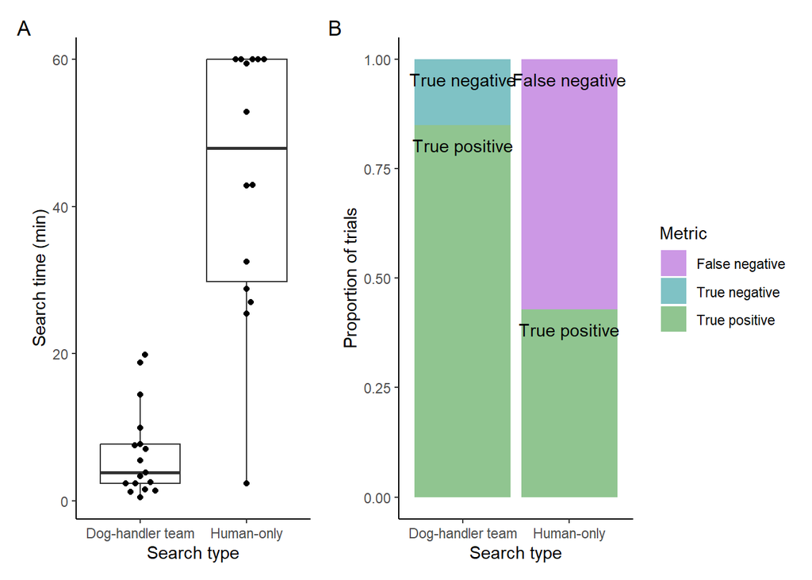

```r
combined_plot <- plot2 + plot1 +
  plot_annotation(tag_levels = 'A')
combined_plot
```

```r
ggsave("times & performance.png", height = 10, width = 20, units = "cm", dpi = 300)
```